# Combine component models to estimate Years of Life Lost

David McAllister 17 December, 2020

# Years of Life Lost for men assuming age and comorbidity are associated. The correlation between comorbidities was estimated assuming that the association between comorbidities was maximal.

This document combines the comorbidity, age and survival model outputs to estimate years of life lost. It can be rendered for men and women, and assuming that age and comorbidity are associated or independent. This particular report is for men and assumes that age and comorbidity are associated.

It also allows for sensitivity analyses on the correlation between comorbidities. This analysis is

one where comorbidities have the maximal possible correlation (although hypertension is treated as a non-disease (ie we indeuce a strong negative correlation, because the in the model hypertension is assocaited wiht a lower mortality) .

```r
library(tidyverse)
```

# Functions

```r
SurvGomp <- function(t, start, ...) {
  # This is a modified version of the summary function (survival part)
  # from flexsurv::summary.flexsurvreg, only difference is triple colon as
  # workhorse function undereath (written in c++) is hidden from users
  ret <- (1 - flexsurv:::pgompertz_work(t, ...))/(1-flexsurv:::pgompertz_work(start, ...))
  ret[t<start] <- 1
  ret
}
 # example of this function
a <- SurvGomp(t = 41:130, start = 50, shape = 0.10345, rate = exp(-11.0345),
              lower_tail = TRUE, give_log = FALSE)
```

# Inputs to synthesis

Read in simulated patients from comorbidity model, age-sex distribution from the Istituto Superiore di Sanità (ISS report), the WHO global burden of disease life tables and the age distributions from the age models.

```r
if(params$correlation_como == "converged")   italy <- readRDS("Data/SimulatedProfilesConverged.Rds")
if(params$correlation_como == "unconverged") italy <- readRDS("Data/SimulatedProfilesUnconverged.Rds")
if(params$correlation_como == "maximal") italy <- readRDS("Data/highest_cor_como.Rds")
if(params$correlation_como == "independent") italy <- readRDS("Data/independent_como.Rds")

names(italy) <- str_to_lower(names(italy))
italy <- as.matrix(italy)

age_sex <- read_tsv("Data/age_distribution_italian_deaths.txt")

if(params$sex == "men") {
  my_vcov <- read_csv("Data/sail_outputs/male_vcov.csv")[,-1]
  my_coef <- read_csv("Data/sail_outputs/male_coef.csv")
  if(params$correlation == "associated") {
    if(params$sd_como_age == "low") {age_smpls <- readRDS("Data/age_selection_male_0_5.Rds")}
    if(params$sd_como_age == "high"){age_smpls <- readRDS("Data/age_selection_male_1.Rds")}
    }
  if(params$correlation == "independent") age_smpls <- readRDS("Data/age_selection_no_comorbid_male.Rds")
  who <- read_csv("Data/sail_outputs/who_compare_men.csv")

}

if(params$sex == "women") {
  my_vcov <- read_csv("Data/sail_outputs/female_vcov.csv")[,-1]
  my_coef <- read_csv("Data/sail_outputs/female_coef.csv")
  if(params$correlation == "associated") {
    if(params$sd_como_age == "low") {age_smpls <- readRDS("Data/age_selection_female_0_5.Rds")}
    if(params$sd_como_age == "high"){age_smpls <- readRDS("Data/age_selection_female_1.Rds")}
  }
  if(params$correlation == "independent") age_smpls <- readRDS("Data/age_selection_no_comorbid_female.Rds")
  who <- read_csv("Data/sail_outputs/who_compare_women.csv")

}

my_vcov <- as.matrix(my_vcov)
rownames(my_vcov) <- colnames(my_vcov)
my_coef_vect <- my_coef[,2, drop = TRUE]
names(my_coef_vect) <- my_coef[,1, drop = TRUE]
my_coef <- my_coef_vect
rm(my_coef_vect)


who_reference <- read_tsv("Data/who_mortality_table.txt")
```

# WHO life tables based YLL

The following uses the proportions in each age who died and the WHO GBD 2010 life tables to estimate the YLL.

```r
age_sex %>% select(-age_point) %>%
  spread(sex, n) %>%
  knitr::kable()
```

| age_bands | men | women |
| --- | --- | --- |
| 30-39 | 14 | 3 |
| 40-49 | 49 | 18 |
| 50-59 | 190 | 53 |
| 60-69 | 607 | 154 |
| 70-79 | 1847 | 556 |
| 80-89 | 1808 | 894 |
| 90+ | 274 | 334 |

```r
age_sex_whole <- age_sex %>%
    filter(sex == params$sex) %>%
    mutate(prp = n/sum(n),
           age_mean = prp*age_point)

age_sex_restr <- age_sex %>%
    filter(sex == params$sex, age_point >=50) %>%
    mutate(prp = n/sum(n),
           age_mean = prp*age_point)

## Mean age
mean_age_whole <- age_sex_whole %>%
  pull(age_mean) %>%
  sum() %>%
  round(1)

mean_age_restricted <- age_sex_restr %>%
  pull(age_mean) %>%
  sum() %>%
  round(1)

## estimate yll using WHO life expectancy and age distribution alone ----
who_reference <- who_reference %>%
  group_by(map2italy) %>%
  summarise(expected_remain = mean(expected_remain)) %>%
  ungroup()
yll_mean_who_whole <- who_reference %>%
  inner_join(age_sex_whole %>% select(map2italy = age_point, prp)) %>%
  mutate(res = expected_remain * prp) %>%
  pull(res) %>%
  sum() %>%
  round(1)
yll_mean_who_restricted <- who_reference %>%
  inner_join(age_sex_restr %>% select(map2italy = age_point, prp)) %>%
  mutate(res = expected_remain * prp) %>%
  pull(res) %>%
  sum() %>%
  round(1)
```

The mean age for the ISS deaths was 77.4 overall and 77.9 when people who died aged <50 were excluded from the calculation.

The estimated years of life lost obtained by applying the age distributions from the ISS report to these tables was 14.4 per person using the whole cohort and 14 after excluding those aged under 50.

# Combining samples from survival models, age models and comorbidity models

The following combines 10,000 samples from survival models, age models and comorbidity models to estimate the age, sex and comorbidity specific life expectancy and subsequently years of life lost.

## Age distributions

The following shows the modelled age-distribution of the ISS data (based on the published counts of patients in each age band). The grey bars are for the simulated data and the coloured bars are the original data (assuming a uniform distribution within each age-band).

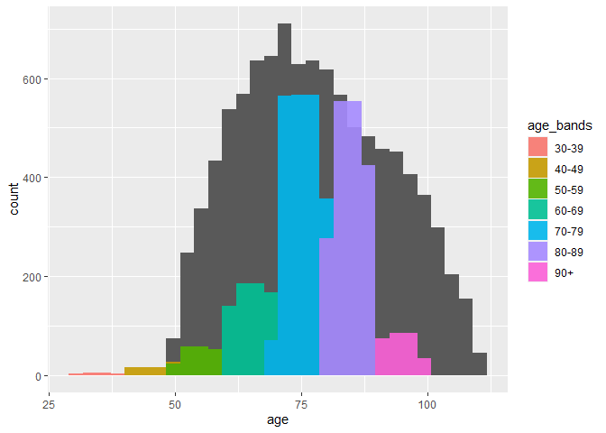

```r
## Sum conditions to Calculate comorbidity count
italy_count <- rowSums(italy)
age_tibble <- tibble(comorbidity_count = italy_count, age = age_smpls)

## spread ages along range of possible values to allow comparison
iss <- age_sex %>%
  filter(sex == params$sex) %>%
  select(age_bands, age_point, n) %>%
  group_by(age_bands) %>%
  nest()
iss$age <- map(iss$data, ~ rep(.x$age_point, .x$n))
iss$age <- map(iss$age, ~ .x + seq(-5, 4, length.out = length(.x)))

iss <- iss %>%
  select(age) %>%
  unnest(cols = c(age))
plot_ages1 <- ggplot(age_tibble, aes(x = age)) +
  geom_histogram() +
  geom_histogram(data = iss, mapping = aes(fill = age_bands), alpha = 0.9)
plot_ages1
```

Here the above histogram is broken down by the comorbidity count.

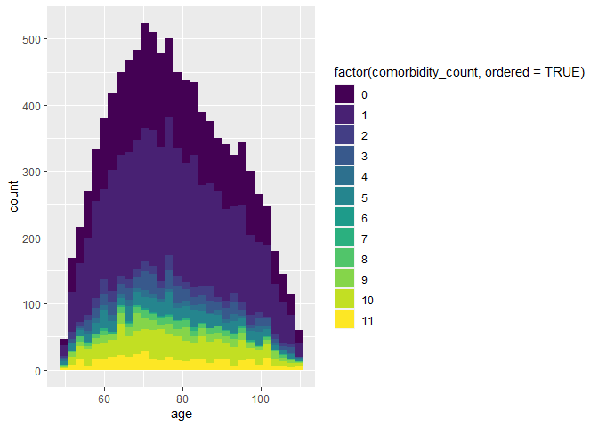

```r
plot_ages2 <- ggplot(age_tibble, aes(x = age)) +
  geom_histogram(mapping = aes(fill = factor(comorbidity_count, ordered = TRUE)))
plot_ages2
```

## Comorbidity counts

```r
como_tbl <- tibble(`Comorbidity count` = italy_count) %>%
  group_by(`Comorbidity count`) %>%
  summarise(N = length(`Comorbidity count`)) %>%
  mutate(Percentage = round(100* N /sum(N),2))
knitr::kable(como_tbl)
```

| Comorbidity count | N | Percentage |
| --- | --- | --- |
| 0 | 2732 | 27.32 |
| 1 | 4134 | 41.34 |
| 2 | 342 | 3.42 |
| 3 | 428 | 4.28 |
| 4 | 171 | 1.71 |
| 5 | 467 | 4.67 |
| 6 | 15 | 0.15 |
| 7 | 41 | 0.41 |
| 8 | 193 | 1.93 |
| 9 | 309 | 3.09 |
| 10 | 759 | 7.59 |
| 11 | 409 | 4.09 |

Here the above histogram is shown as small multiples having stratified by comorbidity count.

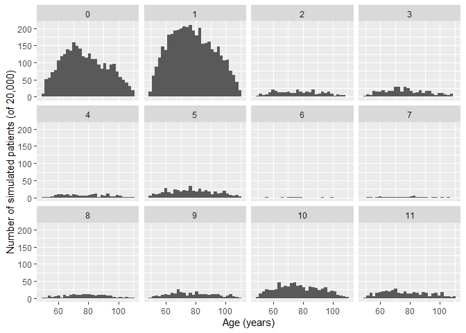

```r
plot_ages3 <- ggplot(age_tibble, aes(x = age)) +
  geom_histogram() +
  facet_wrap( ~ comorbidity_count) +
  scale_x_continuous("Age (years)") +
  scale_y_continuous(name = "Number of simulated patients (of 20,000)")
plot_ages3
```

The following is a check that the names of the comorbidities are the same in the samples from the survival models and comorbidity estimates. The comorbidity samples should have no differences (character 0) and the coefficients and variance-covariance matrix from the survival model shoudl be identical apart from the shape and rate parameters.

```r
name_cols <- c("atr_fib", "cancer", "copd", "demen", "diab",
               "h_fail", "hypert", "ihd", "renal", "liver", "stroke")
name_cols_age <- c("atr_fib:age",
                   "cancer:age", "copd:age", "demen:age", "diab:age", "h_fail:age",
                   "hypert:age", "ihd:age", "renal:age", "liver:age", "stroke:age")

setdiff(colnames(italy), name_cols)
```

```
## character(0)
```

```r
setdiff(names(my_coef), c(name_cols, name_cols_age))
```

```
## [1] "shape" "rate"
```

```r
setdiff(colnames(my_vcov), c(name_cols, name_cols_age))
```

```
## [1] "shape" "rate"
```

## Design matrix

The following code multiplies the comorbidity samples, which is a prediction matrix by age to get age:comorbidity interactions

```r
italy_ages <- age_smpls * italy
head(italy_ages)
```

```
##      atr_fib cancer copd demen     diab h_fail   hypert     ihd renal liver stroke
## [1,]  0.0000      0    0     0 104.7950      0 104.7950  0.0000     0     0      0
## [2,] 72.2617      0    0     0  72.2617      0  72.2617 72.2617     0     0      0
## [3,]  0.0000      0    0     0   0.0000      0   0.0000  0.0000     0     0      0
## [4,]  0.0000      0    0     0   0.0000      0   0.0000  0.0000     0     0      0
## [5,]  0.0000      0    0     0   0.0000      0  90.7491  0.0000     0     0      0
## [6,]  0.0000      0    0     0   0.0000      0   0.0000  0.0000     0     0      0
```

## Sampling from survival model

THe following code samples from the survival model to obtain 10,000 samples of the coefficients.

Check data are correctly aligned then obtain 10,000 samples.

```r
all(names(my_coef) == colnames(my_vcov))
```

```
## [1] TRUE
```

```r
surv_smpls <- mvtnorm::rmvnorm(10000, my_coef, my_vcov)

a <- (colMeans(surv_smpls) %>% round(3))
b <- apply(surv_smpls, 2, sd) %>% round(3)
knitr::kable(tibble("_" = names(a), "est" = a, se = b))
```

| _ | est | se |
| --- | --- | --- |
| shape | 0.097 | 0.001 |
| rate | -11.044 | 0.048 |
| atr_fib | -0.122 | 0.101 |
| cancer | 1.520 | 0.077 |
| copd | 2.134 | 0.079 |
| demen | 1.718 | 0.146 |
| diab | 0.934 | 0.070 |
| h_fail | 1.280 | 0.109 |
| hypert | -0.177 | 0.066 |
| ihd | 0.406 | 0.106 |
| renal | 0.148 | 0.085 |
| liver | 4.057 | 0.169 |
| stroke | 0.807 | 0.094 |
| atr_fib:age | 0.005 | 0.001 |
| cancer:age | -0.016 | 0.001 |
| copd:age | -0.020 | 0.001 |
| demen:age | -0.009 | 0.002 |
| diab:age | -0.010 | 0.001 |
| h_fail:age | -0.011 | 0.001 |
| hypert:age | 0.003 | 0.001 |
| ihd:age | -0.003 | 0.001 |
| renal:age | 0.001 | 0.001 |
| liver:age | -0.047 | 0.002 |
| stroke:age | -0.006 | 0.001 |

## Estimating the linear predictor for each of the 10,000 iterations

Note that these multiplications are not matrix multiplications. They are element-wise multiplications of identically positioned elements in each matrix. Each part of the linear predictor is calculated separately, these are then summed to obtain the linear predictor based on the age and comorbidity distributions of the simulated patients.

```r
## shape parameter
shpe       <- surv_smpls[ , "shape"]

## Intercept (rate parameter)
cept_lp    <- surv_smpls[ , "rate"]
```

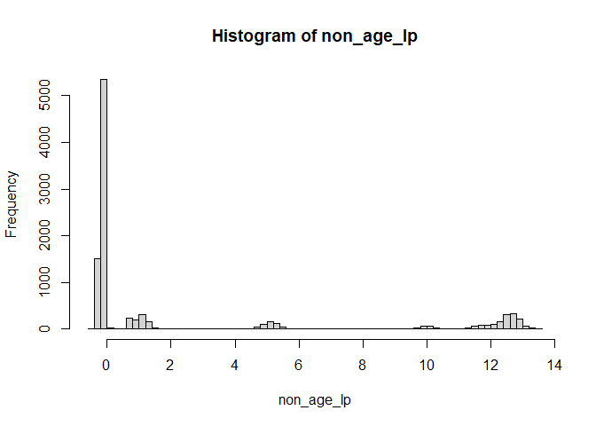

```r
## This multiplies the covariate level (binary) with the simulated coefficeints
non_age_lp <- italy[,name_cols] * (surv_smpls[, name_cols])
## This adds these together to get the non-age dependent part of the linear predictor
non_age_lp <- rowSums(non_age_lp)
hist(non_age_lp, breaks = 100)
```

```r
## Part of lp dependent on age
# ensure_matrices_match
all(paste0(name_cols, ":age") == name_cols_age )
```

```
## [1] TRUE
```

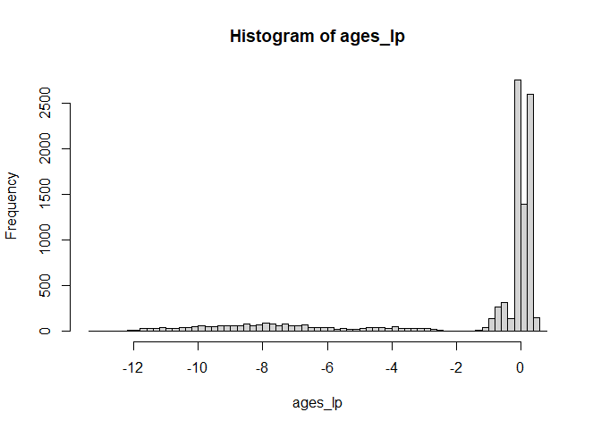

```r
## Loop through the different age groups to get the part of the LP with age interactions
ages_lp <-  rowSums(italy_ages[, name_cols]  * surv_smpls[, name_cols_age])
hist(ages_lp, breaks = 100)
```

The following sums the components of the linear predictor.

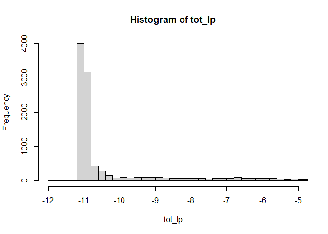

```r
## total lp
tot_lp <- cept_lp + non_age_lp + ages_lp
hist(tot_lp, breaks = 50, xlim = c(-12, -5))
```

The following transforms the linear predictor onto the rate scale.

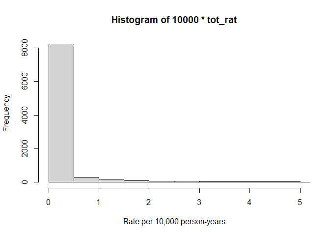

```r
tot_rat <- exp(tot_lp)
hist(10000*tot_rat, breaks = 500, xlim = c(0,5), xlab = "Rate per 10,000 person-years")
```

## Estimate the survival at each time-point (3-monthly)

The following uses a function from the flexsurv package called by summary.flexsurv to obtain survival probabilities at each follow-up time. Where the time is before the patients age at baseline (in this case the age at death in the ISS data) the survival probability is by definition one.

```r
times_vect <- seq(50, 150, 0.25)
tot_surv <- matrix(NA, nrow = 10000, ncol = length(times_vect))
for(i in 1:10000){
  a <- SurvGomp(t = times_vect, start = age_smpls[i], shape = shpe[i], rate = tot_rat[i],
                lower_tail = TRUE, give_log = FALSE)
  tot_surv[i,] <- t(a)
}

tot_surv_na <- matrix(is.na(tot_surv), nrow = 10000, ncol = length(times_vect))
tot_surv_na <- rowSums(tot_surv_na)
tot_surv_na <- any(tot_surv_na >=1)
tot_surv_na <- sum(tot_surv_na)
if(tot_surv_na >=1) warning(paste0("The SurvGomp function returned NaN for ", tot_surv_na, " simulated patients"))
if(tot_surv_na >=5) stop()
```

### The following plots show the survival distribution for a random sample of 3 notional patients.

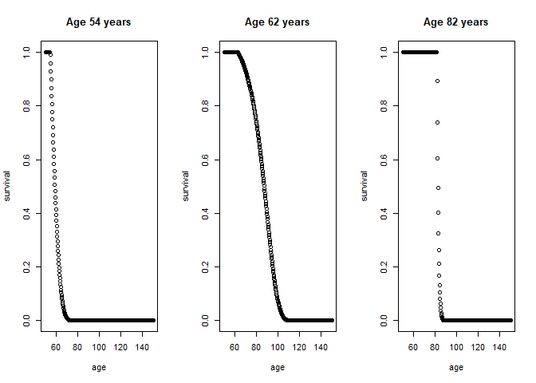

```r
par(mfrow=c(1,3))
for(k in 1:3){
  i <- sample(1:10000, 1)
  plot(times_vect, tot_surv[i,], xlab = "age", ylab = "survival", main = paste0("Age ", age_smpls[i] %>%  round(), " years"))
}
```

```r
par(mfrow=c(1,1))
```

## Survival distribution for all patients stratified by age and comorbidity count

The following figures show this for all patients according to age, and comorbidity.

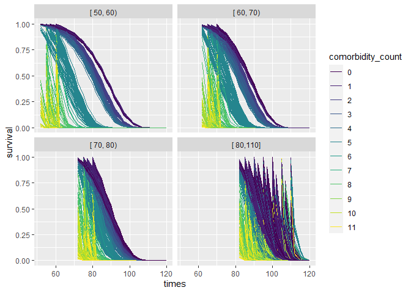

```r
surv_all <- as.data.frame(tot_surv)
names(surv_all) <- times_vect
surv_all <- surv_all[ , times_vect %in% seq(50, 120, 2.5)]
surv_all <- surv_all %>%
  mutate(pt = 1:10000)
surv_all <-  surv_all %>%
  as_tibble() %>%
  mutate(comorbidity_count = italy_count,
         age = age_smpls) %>%
  gather("times", "survival", -pt, -comorbidity_count, -age) %>%
  mutate(times = as.integer(times),
         comorbidity_count = factor(comorbidity_count, ordered = TRUE)) %>%
  arrange(pt, times)
surv_all <- surv_all %>%
  filter(age <= times, times <= 120) %>%
  mutate(age_bands = Hmisc::cut2(age, cuts = seq(50, 80, 10)))

plot_surv <- ggplot(surv_all, aes(x = times, y = survival, colour = comorbidity_count, group = pt)) +
  geom_line() +
  facet_wrap(~ age_bands)
plot_surv
```

## Calculate life expectancy (mean survival) for each patient

The following sums over the distribution of survival on time to obtain the mean survival, which is the life expectancy.

```r
le <- apply(tot_surv, 1, function(x) {
    x <- 1-x
    # calculate proportion who died in the interval
    x <- x - lag(x, default = 0)
    # Calculate the expectation of death
    sum(x * times_vect)
})

le_check <- apply(tot_surv, 1, function(x) {
    x <- 1-x
    # calculate proportion who died in the interval
    x <- x - lag(x, default = 0)
    # Calculate the expectation of death
    sum(x)
})
all(le_check ==1)
```

```
## [1] TRUE
```

```r
saveRDS(le,  paste0("Data/", params$sex, "_", params$correlation, "_", params$correlation_como, "_le_pre_offset.Rds"))
```

## Offset life expectancy to allow for the fact that the LE in Wales is lower than the WHO levels

```r
who <- who %>%
  mutate(who_ratio = who_remain/expect_remain_years,
         who_le_ratio = (who_remain+age)/(expect_remain_years + age))
mean(who$who_le_ratio)
```

```
## [1] 1.050812
```

```r
if(params$sex == "men"){
  who_offset <- case_when(
  age_smpls <= 55 ~ 1.07,
  age_smpls <= 65 ~ 1.06,
  age_smpls <= 75 ~ 1.04,
  age_smpls <= 85 ~ 1.02,
  TRUE ~ 1
)
}
if(params$sex == "women"){
  who_offset <- case_when(
  age_smpls <= 55 ~ 1.04,
  age_smpls <= 65 ~ 1.03,
  age_smpls <= 75 ~ 1.02,
  age_smpls <= 85 ~ 1.01,
  TRUE ~ 1
)
}
le <- le * who_offset
```

## Years of life lost

The following calculates the years of life lost from the age, sex and comorbidity defined survival and the age and comorbidities at death from the ISS data.

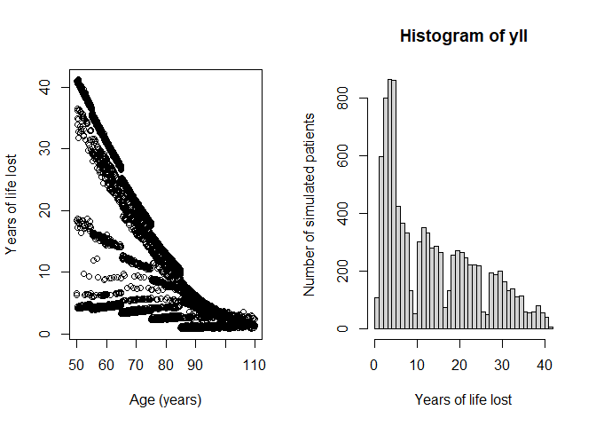

```r
yll <- le - age_smpls
par(mfrow = c(1,2))
plot(age_smpls, yll, xlab = "Age (years)", ylab = "Years of life lost")
hist(yll, breaks = 50, xlab = "Years of life lost", ylab = "Number of simulated patients")
```

## Compare YLL using WHO tables and comorbidity-based assesment

Among those over 50 for which both methods were used, the WHO tables based estimates of YLL, and our estimates which additionally accomodate comorbidity, yielded similar per capita YLL; the values were 14 and 13.69 respectively.

## YLL by age and comorbidity

The following shows the distribution of YLL by age, sex and comorbidity by age categories.

### Table YLL per capita by comorbidity count, and age

```r
yll_df <- tibble(yll = yll) %>%
  mutate(comorbidity_count = factor(italy_count, ordered = TRUE),
         age = round(age_smpls),
         age_cat = Hmisc::cut2(age, cuts = seq(50, 80, 10)))

yll_smry <- yll_df %>%
  group_by(comorbidity_count, age_cat) %>%
  summarise(yll = mean(yll) %>% round(2)) %>%
  rename(`Comorbidity count` = comorbidity_count) %>%
  spread(age_cat, yll)
knitr::kable(yll_smry)
```

| Comorbidity count | [ 50, 60) | [ 60, 70) | [ 70, 80) | [ 80,110] |
| --- | --- | --- | --- | --- |
| 0 | 35.61 | 26.51 | 17.87 | 6.64 |
| 1 | 35.40 | 26.26 | 17.15 | 6.29 |
| 2 | 32.14 | 24.56 | 15.60 | 6.02 |
| 3 | 29.35 | 22.36 | 14.80 | 5.46 |
| 4 | 28.02 | 21.15 | 13.61 | 4.80 |
| 5 | 16.50 | 13.38 | 9.74 | 4.94 |
| 6 | 12.03 | 9.51 | 8.12 | 3.84 |
| 7 | 9.19 | 8.39 | 6.63 | 4.27 |
| 8 | 6.34 | 5.95 | 5.00 | 3.19 |
| 9 | 4.58 | 4.30 | 3.53 | 1.83 |
| 10 | 4.27 | 4.04 | 3.24 | 1.50 |
| 11 | 4.19 | 3.92 | 3.06 | 1.34 |

## Plot distribution of years of life lost by age and comrobidity count

Plot distributions of YLL overall, then stratified by age, with colour indicating the comorbidity count.

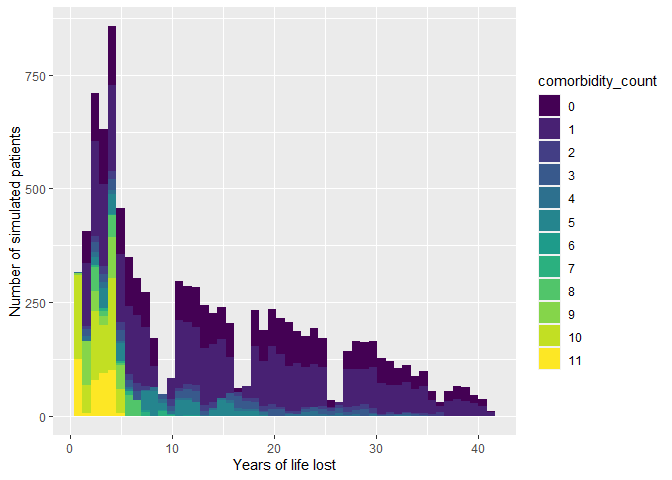

```r
plot1_yll <- ggplot(yll_df, aes(x = yll,  fill = comorbidity_count)) +
  geom_histogram(bins = 50) +
  scale_y_continuous("Number of simulated patients") +
  scale_x_continuous("Years of life lost")
plot1_yll
```

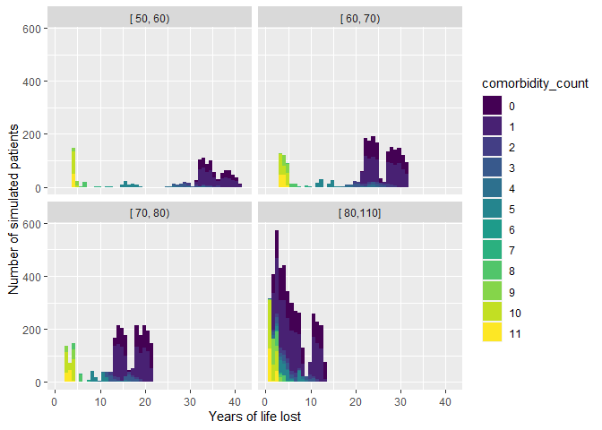

```r
plot2_yll <- plot1_yll +
  facet_wrap(~ age_cat)
plot2_yll
```

## Crude approach to obtain 95% credible interval

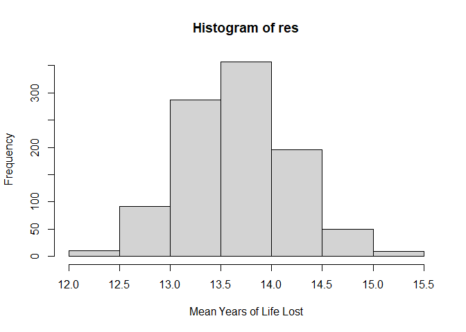

```r
res <- map_dbl(1:1000, ~  mean(sample(yll, 404, replace = TRUE)))
hist(res, xlab = "Mean Years of Life Lost")
```

```r
est <- mean(res, na.rm = TRUE) %>% round(1)
lci_uci <- quantile(res, probs = c(0.025, 0.975), na.rm = TRUE) %>% round(1) %>% paste(collapse = "-")
est
```

```
## [1] 13.7
```

```r
lci_uci
```

```
## [1] "12.6-14.7"
```

The mean and (95% credible interval) for the years of life lost using this approach was 13.7 (95% CI 12.6-14.7).

```r
mylist <- list(est, lci_uci, mean_age_restricted, mean_age_whole,
               plot_ages1, plot_ages2, plot_ages3, plot_surv, plot1_yll, plot2_yll,
               who, yll_df, yll_mean_who_restricted, yll_mean_who_whole, yll_smry)
saveRDS(mylist, paste0("Output_rmd/",
                       params$sex, "_",
                       params$correlation, "_",
                       params$correlation_como, "_",
                       params$sd_como_age,
                       ".Rds"))
```